# How is the Digital Economy Governed?

Stephen Weymouth

Dean’s Professor

2026-11-23

# U.S. law shields Meta from most liability for what its users post. China has blocked its Facebook app since 2009. In 2023 it was fined €1.2 billion under the European Union’s privacy law.

## Your IB Voice

One firm, three governments

The United States shields Meta, China blocks it, and the European Union fines it. Explain why governments treat the same firm so differently.

**10 minutes** · Individual · Notes permitted

# What did the United States leave to the firms?

## A 1996 law shields platforms from most liability

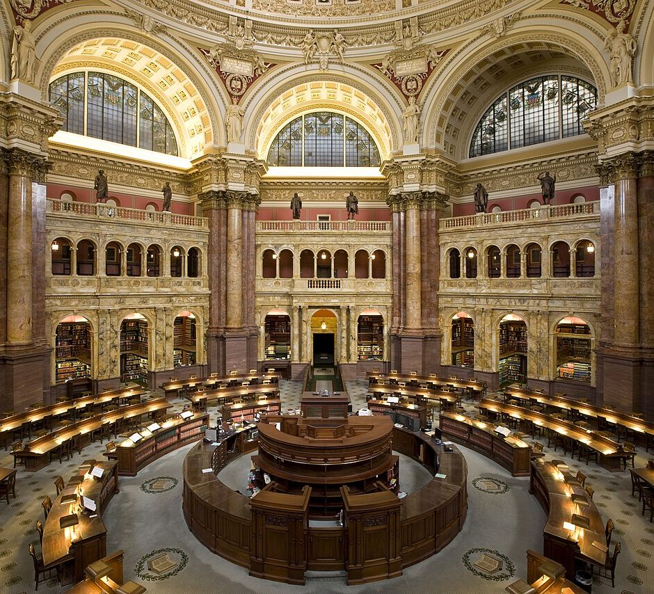

The Main Reading Room of the Library of Congress, where the Act was signed. Carol M. Highsmith, [*Main Reading Room, Library of Congress*](https://commons.wikimedia.org/wiki/File:LOC_Main_Reading_Room_Highsmith.jpg), 2009 · Wikimedia Commons, public domain

> *No provider or user of an interactive computer service shall be treated as the publisher or speaker of any information provided by another information content provider.*

Section 230(c)(1) of the Communications Decency Act, 1996

President Clinton signed the Act in 1996.

Congress has passed no comprehensive consumer privacy law. The U.S. left decisions about speech and personal data to the firms.

## Platforms police speech under their own rules

Bradford, *Digital Empires*, 2023, p. 3; Facebook, March 18, 2019.

No government made either call, and Bradford writes that regulators have left such decisions to the platforms.

## Who should decide

Who should decide what stays online: the platform, the government, or a court?

## The U.S. left digital firms largely unregulated

Bradford, *Digital Empires*, 2023, pp. 2–4.

The result is *platform power* over markets, politics, public debate, and personal data.

Bradford calls this the *market-driven model*, which trusts markets and allocates control over data to firms.

## Five firms’ combined revenue nearly doubled since 2020

Company annual reports and results releases for 2020 and 2025.

Together: $1.07 trillion in 2020 and $2.02 trillion in 2025.

Bradford reports that they bought 770 startups over three decades.

Bradford writes that weak antitrust enforcement let these firms “amass even more power through a staggering number of acquisitions.”

# What does China’s state want from its firms?

# China required Google to censor its search results, and for four years Google did. In 2010 it stopped and moved its search engine to Hong Kong. Users left flowers outside its Beijing office.

## Behind the Great Firewall, Chinese firms grew

Wikipedia, “List of websites blocked in mainland China”; Tencent, third-quarter results, 2026.

WeChat, known in China as Weixin, has more than 1.4 billion monthly users.

Bradford writes that, in return for light regulation, Chinese firms censored and watched their users for the state.

## In 2020 China cracked down on its tech giants

China’s State Administration for Market Regulation and Cyberspace Administration; Reuters.

Alibaba, Tencent, Meituan, Baidu, and JD.com lost about $1.1 trillion in market value by July 2023.

Regulators cited monopoly, data security, and financial risk, and from 2021 China tied the campaign to “common prosperity.”

# Why would a government that wants to lead the world in technology punish its most successful technology firms?

## Serving the state: the state-driven model

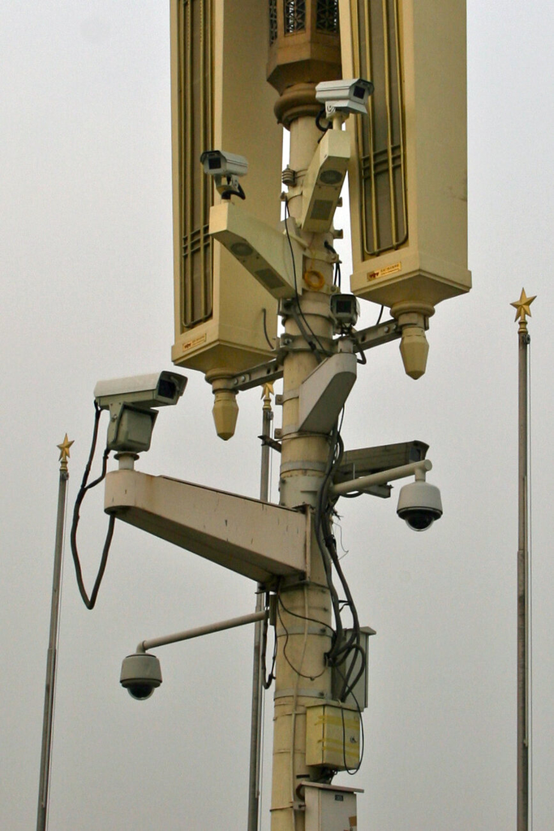

Andrey Belenko, [*Surveillance camera at Tiananmen Square*](https://commons.wikimedia.org/wiki/File:Surveillance_camera_at_Tiananmen_Square,_2009.jpg), 2009 · Wikimedia Commons, CC BY 2.0

The state uses technology to grow the economy and to keep political control.

Firms carry out its censorship and surveillance, and the state decides how powerful they may become.

Bradford calls this the *state-driven model*, which shows that “freedom is not inherent in the character of the internet.”

# What does the European Union protect?

## One complaint ended two data agreements

[figure not shown]

Max Schrems in Vienna, 2016. Manfred Werner, [Wikimedia Commons](https://commons.wikimedia.org/wiki/File:Max_Schrems_2016_b.jpg), CC BY-SA 3.0

[figure not shown]

EU law gives a citizen a right to data protection that he can enforce against a firm and against an agreement between governments.

## The EU regulates tech firms through five laws

[figure not shown]

Treaty of Rome; Regulations (EU) 2016/679, 2022/1925, 2022/2065, and 2024/1689, on EUR-Lex.

Under each law a regulator can fine a firm a share of its worldwide sales, and a court reviews the fine afterward.

## The EU’s largest tech fines fell on U.S. firms

European Commission; Court of Justice of the EU; Ireland’s Data Protection Commission; Italy’s competition authority.

Meta’s fine applied the 2020 Schrems ruling to data it kept sending under contract clauses.

The U.S. calls the fines protectionism, and the EU calls them the defense of rights and fair markets.

## Protecting citizens: the rights-driven model

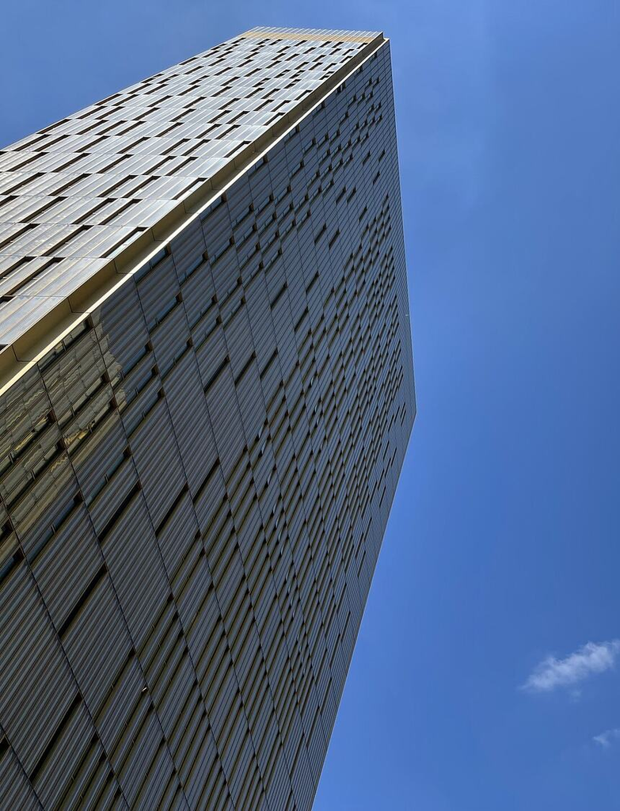

Alf van Beem, [*Tours de la Cour de justice de l’Union européenne*](https://commons.wikimedia.org/wiki/File:Tours_de_la_Cour_de_justice_de_l%27Union_europ%C3%A9enne_photo_3.jpg), 2022 · Wikimedia Commons, CC0

The government regulates firms to protect privacy, dignity, and democracy.

Motivated by concerns that tech firms “do not understand the pillars of constitutional democracy.”

Bradford calls this the *rights-driven model*: its rules are meant to protect citizens from firms and from the state.

## Each model competes globally

Bradford, *Digital Empires*, 2023, Introduction.

Bradford calls the three powers behind these models *digital empires*, which she says are both admired and reviled abroad.

# Why did three models emerge?

## Data is a new input with insecure property rights

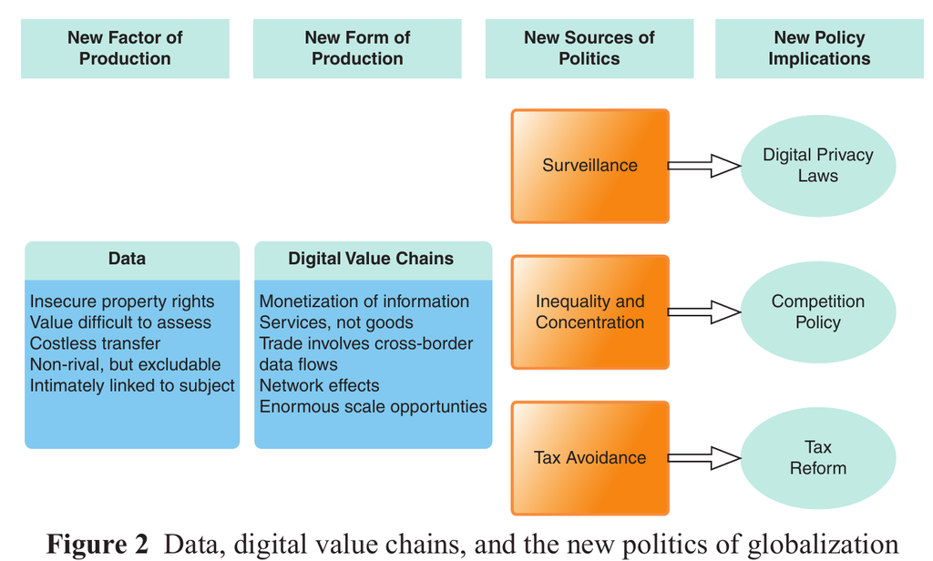

Weymouth, *Digital Globalization*, 2023, Figure 2.

Data is the central input of the digital economy.

Firms turn it into revenue, and that raises fights over privacy, concentration, and taxes.

No rule settles who owns data, so each government decides who controls it.

## The three models differ on who controls data

Weymouth, *Digital Globalization*, 2023, pp. 51–52.

Whoever controls data sets the terms on which a firm can collect it, move it, and profit from it.

# East Germany’s secret police kept one informant for every 89 citizens and left 111 kilometers of files. Bradford says this history is one reason the EU treats privacy as a fundamental right.

## Europe regulates an industry dominated by U.S. firms

[CompaniesMarketCap](https://companiesmarketcap.com/tech/largest-tech-companies-by-market-cap/): the 20 most valuable tech firms on November 20, 2026.

The United States is home to 14 of the 20 most valuable tech firms, and the EU to one.

Europe’s largest fines therefore fall mostly on foreign firms, and the U.S. calls them protectionism.

Critics blame Europe’s rules for its lack of giants, while Bradford blames other policies and argues that more regulation need not mean less innovation.

## Three forces shape each model

[figure not shown]

Weymouth, *Digital Globalization*, 2023, p. 6; Bradford, *Digital Empires*, 2023, pp. 7–10; the cell entries are the instructor’s.

No single force explains a model: ideas and values, firms’ interests, and political institutions each do part of the work.

# What do the models mean for a firm?

# In 2022 Meta warned that it might pull Facebook and Instagram out of Europe. In 2023 it was fined €1.2 billion under EU privacy law, and it stayed. What would make leaving cheaper than complying?

## Europe’s region supplies a quarter of these sales

Company annual reports (Form 10-K), 2025. Apple’s Europe segment includes India, the Middle East, and Africa.

Leaving the EU would put up to a quarter of a firm’s revenue at stake.

A new EU–U.S. data framework in July 2023 also ended Meta’s legal conflict.

Apple earns about 16 percent of its sales in Greater China, where a state-owned firm holds mainland users’ iCloud accounts.

Market access is each government’s lever, and Bradford writes that the EU’s power lasts only while firms find complying cheaper than leaving.

## Meta earns more in Europe than a fine can cost

[figure not shown]

Meta Platforms, Form 10-K for 2025; Regulation (EU) 2022/1925, Article 30; Ireland’s Data Protection Commission, May 22, 2023.

EU law measures a fine against a firm’s worldwide sales, so a rule for one market puts the whole business at risk.

## EU rules sometimes spread globally

Directive (EU) 2022/2380; Apple developer news, 2024 to 2026.

The *Brussels Effect* is the spread of EU rules beyond the EU, through firms that apply them worldwide and through governments that replicate them.

## A firm cannot always obey two governments

Bradford, *Digital Empires*, 2023, Introduction; U.S. and Chinese laws and orders.

Bradford calls a clash between governments a *horizontal battle* and a clash between a government and tech firms a *vertical battle*. Obeying one government can mean breaking another’s law.

## Open digital trade first requires shared rules

[figure not shown]

*Digital Globalization: Politics, Policy, and a Governance Paradox*, Cambridge University Press, 2023

Paradoxically, for digital globalization to flourish, the multinationals that currently dominate digital markets must first be restrained.

*Digital Globalization*, 2023

I call this the *digital globalization paradox*, and without shared rules firms face “a web of compliance requirements to sell digital services abroad.”

## A firm has four responses to conflicting rules

[figure not shown]

Company announcements, 2010 to 2026; the four responses are the instructor’s.

Each step to the right gives up more of a firm’s scale, and the last gives up the market.

## Is the US model diffusing?

[figure not shown]

Australia’s eSafety Commissioner; European Commission; MultiState; White House; U.S. State Department.

In 2023 Bradford wrote that the American model was fading, with democracies moving toward Europe’s model and other states toward China’s.

## Takeaways

What should a global firm know about the three models?

The United States leaves the rules to its firms, China makes its firms serve the state, and the EU regulates firms to protect citizens’ rights.

Each model reflects ideas and values, firms’ interests, and political institutions.

The models reach a firm through market access, fines capped by worldwide sales, and compliance burdens.

A global firm must choose among one product, customized products, a split, and leaving a market.